# Math 472/572, Tuesday, April 19, 2022

# More Modeling – But Classification

For the past few weeks we’ve worked with models for data. We restricted ourselves to predicting **numerical** values of response (dependent) variables based on numerical (and at times categorical) predictor (independent) variable values. Your second test focuses on building such models.

Tonight we will consider what we can do if the value we want to predict has a **categorical** value. In particular, we’ll take a look at two different classification methods: - Linear Discriminant Analysis (LDA), and - k Nearest Neighbor (KNN) for classification. Note, in most cases, Dr. McNelis believes she read that it’s best that our response variable should be a **factor** in R.

# Linear Discriminant Analysis (LDA)

Dr. McNelis is not as well-versed with this, but the primary idea is that we want to try to find a linear combination of our predictor variables (which must all be NUMERICAL variables!) that helps to separate or observations based on a CATEGORICAL response variable values. For those with linear algebra, think of the linear combinations of variables defining (hyper)planes that can slice up our vector space. By finding these planes, they can cut up our space and help us find a direction from which to view our space to clearly separate out our observations in terms of this categorical variable.

## Training and Testing Sets

For this, and our other model method, we must take a data set in which we have known values of our predictor variables as well as their associated (categorical) response variable. We will then break this data set up into two sets of observations (of all variable values), a training set and a testing set. You will typically have a much larger training set than testing set (e.g. 70%/30% or 80%/20% splits of the original data). We will use the training data set to develop necessary model parameters and values, so that given a new observation, of which we only have values of our predictor variables, our model will be able to make a prediction as to what value of response would be associated with it. We run our model on our testing data (for which we also have the correct answers) to see how good our model seems.

For the first examples we’ll work with today, we’ll use a data set we’ve seen before and one you’ll find is often used to help explain these models: the `iris` dataset from the `dplyr` library.

```r
library(tidyverse)
library(purrr)

str(iris)
```

```
'data.frame':   150 obs. of  5 variables:
 $ Sepal.Length: num  5.1 4.9 4.7 4.6 5 5.4 4.6 5 4.4 4.9 ...
 $ Sepal.Width : num  3.5 3 3.2 3.1 3.6 3.9 3.4 3.4 2.9 3.1 ...
 $ Petal.Length: num  1.4 1.4 1.3 1.5 1.4 1.7 1.4 1.5 1.4 1.5 ...
 $ Petal.Width : num  0.2 0.2 0.2 0.2 0.2 0.4 0.3 0.2 0.2 0.1 ...
 $ Species     : Factor w/ 3 levels "setosa","versicolor",..: 1 1 1 1 1 1 1 1 1 1 ...
```

Let’s suppose we want to use 80% of our data set as our training data and the other 20% as our testing data. We’ll want to take a random sample of our observations from our data set. Use the `sample` function to help us do this.

```r
#  We can set a seed for our random number generator to assure that
#  we will all have the same results.
set.seed(20220419)

#  Generate a list of row numbers (observation numbers) that we'll use
#  from our data set as the training observations.  Remember, we want
#  this to account for roughly 80% of our data.

sample_rows <- sample(1:nrow(iris), ceiling(.80 * nrow(iris)), replace = FALSE)
sample_rows
```

```
  [1]  58  42  83  61  20  85 119  75  80  70  57 117 111 102  76  82 123  55  86  54  52 137 144  65  30   7  95 133  71
 [30]  91  64   1 136  45  22 114 149 126 147 109  26  63  62  24 150 115  27 127 101 128  17 130  39 104  60  78  31  29
 [59] 118  79 100  93  38  33  50  73  74  41 110  77  49  12   4  25  88  67  37  34   8  16  98 120 148  53  21  13   9
 [88]  14 131 140 113   6  99 135 108 112  43  18  15  94 107 146  87  28  90  35  92  32 103   3  56 121 143  69  11  10
[117]  96  44 125  68
```

Before we go further, we’ll take into consideration the fact that the Linear Discriminant Analysis method has a few requirements: - Our predictor variables are all numerical and our response variable is categorical (check mark) - Our numerical preditor variable values are **normalize** i.e. that are all scaled so that differences in original scale does not bias our work. In particular, it is preferable that these values are normally distributed with mean zero and standard deviation of one, so we will work with z-scores of our original variables - It is recommended that predictor variables not have outliers, so we should remove those first before normalizing - Go ahead and remove any observations containing NA’s before you start too

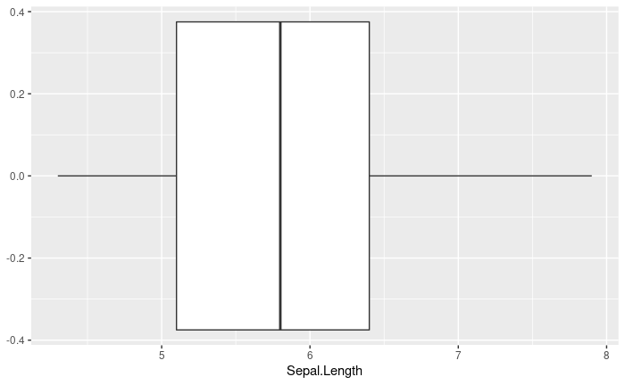

```r
#  Remove any observations with NA.  Note, if you install tidyr, you can
#  use the drop_na() function such as iris <- iris %>% drop_na()
iris <- na.omit(iris)

# Checking for outliers
ggplot(iris) + geom_boxplot(aes(x = Sepal.Length))
```

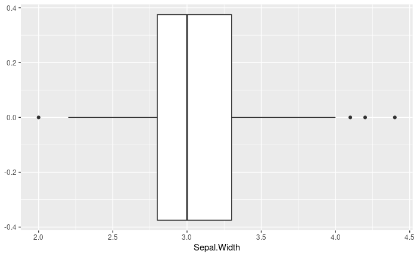

```r
ggplot(iris) + geom_boxplot(aes(x = Sepal.Width))
```

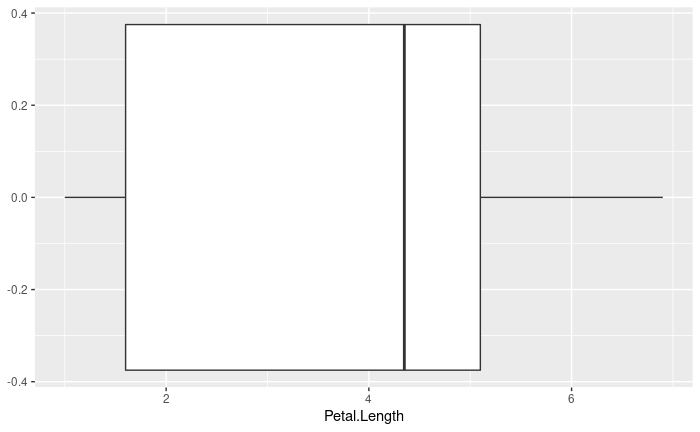

```r
ggplot(iris) + geom_boxplot(aes(x = Petal.Length))
```

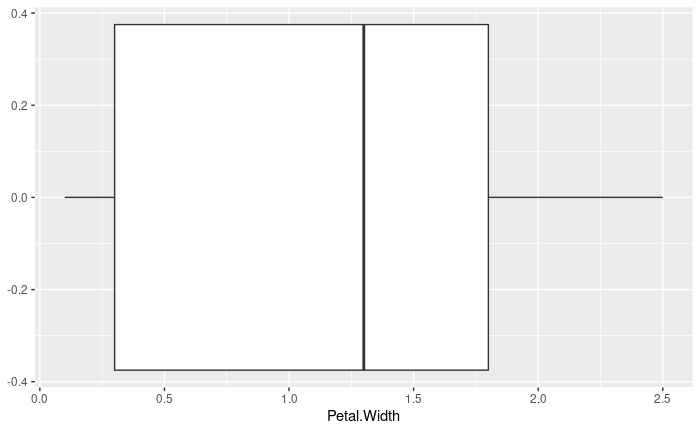

```r
ggplot(iris) + geom_boxplot(aes(x = Petal.Width))
```

```r
# Looks like there are outliers in Sepal.Width. We will remove them.
# Solid dots are mild outliers, which means there are more than 1.5 IQR's from Q3

(SWquartiles <- quantile(iris$Sepal.Width))
```

```
  0%  25%  50%  75% 100%
 2.0  2.8  3.0  3.3  4.4
```

```r
Q3 <- SWquartiles[[4]]
Q1 <- SWquartiles[[2]]
swIQR <- SWquartiles[[4]] - SWquartiles[[2]] # Q3 - Q1

iris <- iris %>% filter(Sepal.Width >= Q1 - 1.5 * swIQR & Sepal.Width <= Q3 + 1.5 * swIQR)

# Since we removed some values from iris, we need to recalculate our sample rows
sample_rows <- sample(1:nrow(iris), ceiling(.80 * nrow(iris)), replace = FALSE)

#  Now let's create a z-score function again, that takes

calc_z_score <- function(x) {
  (x - mean(x)) / sd(x)
}

#  And now we can apply this to all but the last (fifth) column of iris
#  and call it n_iris
iris[1:4] <- iris %>% dplyr::select(1:4) %>% lapply(calc_z_score)
head(iris)
```

|  | Sepal.Length | Sepal.Width | Petal.Length | Petal.Width | Species |
| --- | --- | --- | --- | --- | --- |
| 1 | -0.9073918 | 1.1551740 | -1.369051 | -1.343899 | setosa |
| 2 | -1.1471732 | -0.1015727 | -1.369051 | -1.343899 | setosa |
| 3 | -1.3869546 | 0.4011260 | -1.425933 | -1.343899 | setosa |
| 4 | -1.5068453 | 0.1497767 | -1.312170 | -1.343899 | setosa |
| 5 | -1.0272825 | 1.4065234 | -1.369051 | -1.343899 | setosa |
| 6 | -0.5477198 | 2.1605714 | -1.198407 | -1.080531 | setosa |

```r
#  And check that our mean is zero and standard deviation is one for each
lapply(iris[1:4], mean)
```

```
$Sepal.Length
[1] -3.992433e-16

$Sepal.Width
[1] 1.982571e-16

$Petal.Length
[1] -4.94671e-17

$Petal.Width
[1] -3.929862e-17
```

```r
lapply(iris[1:4], sd)
```

```
$Sepal.Length
[1] 1

$Sepal.Width
[1] 1

$Petal.Length
[1] 1

$Petal.Width
[1] 1
```

Now that this is done, we can split this normalized iris data frame up into our training and testing sets.

```r
#  Define iris_train and iris_test.  Can you do this using filter?
# We had sample_rows which lists the rows to keep for the training set.
iris_train <- iris[sample_rows,]
iris_test <- iris[-sample_rows,]

#  What if you wanted to use the dfname[ , ] notation?
```

Now we’re ready to fit our Linear Discriminant Analysis model. But this is in a special library that we must load first. It’s in the MASS package.

```r
library(MASS)
#  Now get the model.  We'll use the formula input option, i.e. we'll
#  indicate ResponseVar ~ PredVar1 + PredVar2 + .., or more simply
#  ResponseVar ~ . where the ~. means "all other variables"

model <- lda(formula = Species ~ . , data = iris_train)
model
```

```
Call:
lda(Species ~ ., data = iris_train)

Prior probabilities of groups:
    setosa versicolor  virginica
 0.3076923  0.3247863  0.3675214

Group means:
           Sepal.Length Sepal.Width Petal.Length Petal.Width
setosa      -1.11387024   0.7153127   -1.3248100  -1.2963463
versicolor   0.05804369  -0.7167171    0.2326112   0.1011603
virginica    0.83241719  -0.1424900    0.9749943   1.0662255

Coefficients of linear discriminants:
                    LD1         LD2
Sepal.Length  0.8854051  0.03181318
Sepal.Width   0.6992455  0.89911614
Petal.Length -4.5036968 -1.84796357
Petal.Width  -2.2251324  2.19870566

Proportion of trace:
   LD1    LD2
0.9913 0.0087
```

Now that we have our model, we want to see how it performs on our testing data set.

```r
#  See how our model is at determining the correct value for our predictions.
predicted <- predict(model, iris_test[-5])
predicted
```

```
$class
 [1] setosa     setosa     setosa     setosa     setosa     setosa     setosa     setosa     setosa     setosa
[11] setosa     versicolor versicolor virginica  versicolor versicolor versicolor virginica  versicolor versicolor
[21] versicolor versicolor virginica  virginica  virginica  virginica  versicolor virginica  virginica
Levels: setosa versicolor virginica

$posterior
          setosa   versicolor    virginica
11  1.000000e+00 1.120237e-28 8.517561e-54
15  1.000000e+00 1.121821e-36 1.607319e-64
16  1.000000e+00 1.832559e-30 2.035263e-55
19  1.000000e+00 5.334039e-27 5.296399e-51
22  1.000000e+00 6.379746e-30 2.224448e-55
25  1.000000e+00 1.592362e-19 6.075517e-42
26  1.000000e+00 1.022365e-20 1.580730e-42
```

[output cut: 54 more lines]

```r
#  And we can get an idea of what proportion our model correctly classified
mean(predicted$class == iris_test$Species)
```

```
[1] 0.8965517
```

We can also visualize what the LD1 and LD2 represent with the following code, taken from https://www.statology.org/linear-discriminant-analysis-in-r/

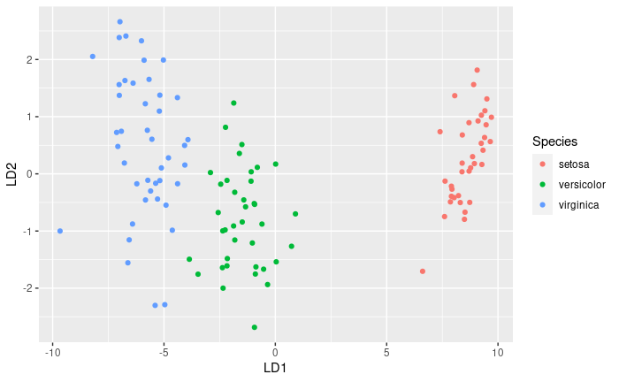

```r
#  Merge the data sets (as columns) from the training set and
#  and the LD1 and LD2 values associated with these from our model
lda_plot <- cbind(iris_train, predict(model)$x)
ggplot(lda_plot, aes(LD1, LD2)) +
  geom_point(aes(color = Species))
```

# k Nearest Neighbor

The k-Nearest Neighbor model also allows us to consider a set of predictor variables (most easily, those that have numerical values or binary categorical values, but it will work with categorical variables with more than two types of answers as well), and a single categorical (as a factor) response variable.

**The Big Idea** The k-Nearest Neighbor model works by considering the location of observations in our (n-1) dimensional predictor space (i.e. the space that consists of all possible values of our n-1 predictor variables) and associates a distance between our unclassified value and all other observations in the set. When these variables are numerical, it’s much easier to conceive of the idea of distance and how to measure distance.

In order to determine the classification of our unknown observation (i.e. we have the n-1 predictor values but no answer for the categorical response variable value), we’ll use our distance metric to determine its distance from all of the other observations in the space. The user will indicate a value for k, and then we’ll consider the k Nearest Neighbors of our unknown observation. We’ll see what values they have of the response variable, and determine which is the most common response. That is the response we’ll assign to our unknown observation. It’s something like the one with the most votes wins.

## k Nearest Neighbors with Only Numerical Predictor Variables

To start with the simpler options, our first example will once again deal with numerical predictor variables only, so we’ll use our iris data set again.

As with our LDA model, we’ll want to normalize our numerical values. We’ve already done this earlier, so we’ll use those same training and testing sets. We will make one adjustments and pull out the Species column from each set and mark it as our training and testing response.

```r
# Take the Species column out of the training set and save it as iris_train_response
iris_train_response <- iris_train %>% dplyr::select(Species)

# Brayan (that fucking nerd) caught that MASS has aselect function that overrode the one in dplyr

# Remove the fifth column from iris_train
iris_train <- iris_train[-5]

#  Do the same for the testing set ...
iris_test_response <- iris_test %>% dplyr::select(Species)
iris_test <- iris_test[-5]
```

We’ll need to use another package to get access to (one of) the k-Nearest Neighbor functions. It’s the “class” package.

```r
library(class)
```

Now we’re ready to try out our KNN function. Note, this one is designed to take a training set, a testing set (of one or more observations), and a factor vector of the correct classifications for the training set (`cl`), as well as the value of k.

```r
#  Now we'll use our k-Nearest Neighbor function

iris_test_predictions <- knn(train = iris_train,
                             test = iris_test,
                             cl = iris_train_response[,1],
                             k = 13)
```

```r
#  We can see the predictions for each observation in our test set and
#  compare them to the correct answer with a confusion matrix (tab)
tab <- table(iris_test_predictions, iris_test_response[,1])
tab
```

```
iris_test_predictions setosa versicolor virginica
           setosa         11          0         0
           versicolor      0          9         0
           virginica       0          2         7
```

```r
#  In order to quantify how well our model did, we'll calculate the
#  number of correct predictions and divide by the total number of
#  predictions to get an accuracy proportion.  We can make a function
#  to do this for us.  Note, the input to the function is a matrix or table.

accuracy <- function(x){sum(diag(x)/(sum(rowSums(x)))) * 100}
accuracy(tab)
```

```
[1] 93.10345
```

## What’s the best value for k?

There’s no perfect formula to determine the best value of k in our k Nearest Neighbor function. The following was taken from https://daviddalpiaz.github.io/r4sl/knn-class.html.

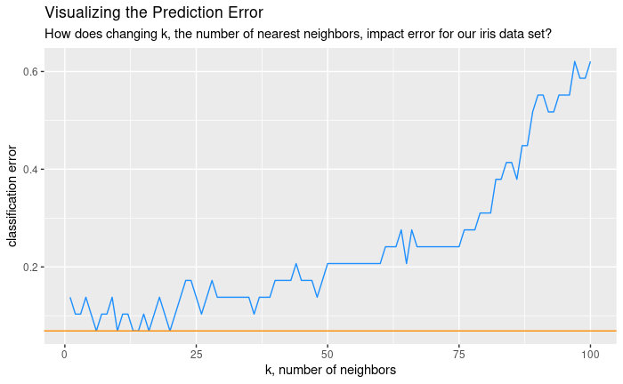

```r
#  Get a range of values to try.  Note, iris has 150 observations
#  so 80% of those would be 120.  So letting k go to 100 is pretty big.

k_to_try = 1:100

#  Make a vector to store our error values
err_k = vector("double", length(k_to_try))

#  Make a helper function to calculate the error associated with a
#  prediction.

calc_class_err = function(actual, predicted) {
  mean(actual != predicted)
}

for (i in seq_along(k_to_try)) {
  pred = knn(train = iris_train,
             test  = iris_test,
             cl    = iris_train_response$Species,
             k     = k_to_try[i])
  err_k[i] = calc_class_err(iris_test_response$Species, pred)
}

explore_k <- tibble(
  k = k_to_try,
  error_val = err_k
)

# Plot error vs choice of k
ggplot(explore_k, aes(x = k, y = error_val)) +
  geom_line(col = "dodgerblue") +
  geom_hline(aes(yintercept = min(error_val)), color = "darkorange") +
  labs(title = "Visualizing the Prediction Error",
       subtitle = "How does changing k, the number of nearest neighbors, impact error for our iris data set?",
       x = "k, number of neighbors",
       y = "classification error")
```

## How to deal with categorical variable values

When we have categorical variables, we will essentially need to convert those to binary values of 0 and 1. This is not too bad when a categorical variable has only two possible values, but it gets a bit more complicated when there are more than two possible values.

It is important to note that we’ll need to make sure that our revised categorical variables are of type integer rather than factor!!

For this, we’ll need a new data set. Let’s try another you’ve seen before, the Palmer Penguins of Test 1.

```r
penguins <-read.csv("https://raw.githubusercontent.com/allisonhorst/palmerpenguins/master/inst/extdata/penguins.csv")

str(penguins)
```

```
'data.frame':   344 obs. of  8 variables:
 $ species          : chr  "Adelie" "Adelie" "Adelie" "Adelie" ...
 $ island           : chr  "Torgersen" "Torgersen" "Torgersen" "Torgersen" ...
 $ bill_length_mm   : num  39.1 39.5 40.3 NA 36.7 39.3 38.9 39.2 34.1 42 ...
 $ bill_depth_mm    : num  18.7 17.4 18 NA 19.3 20.6 17.8 19.6 18.1 20.2 ...
 $ flipper_length_mm: int  181 186 195 NA 193 190 181 195 193 190 ...
 $ body_mass_g      : int  3750 3800 3250 NA 3450 3650 3625 4675 3475 4250 ...
 $ sex              : chr  "male" "female" "female" NA ...
 $ year             : int  2007 2007 2007 2007 2007 2007 2007 2007 2007 2007 ...
```

Before we start working with it, let’s remove any rows with NA’s

```r
peng <- na.omit(penguins)
peng %>% group_by(sex) %>% summarise(count = n())
```

| sex | count |
| --- | --- |
| female | 165 |
| male | 168 |

We’ll also need to normalize our bill_length_mm, bill_depth_mm, flipper_length_mm, and body_mass_g. Note, Dr. McNelis did not mention year, as it’s more of a categorical variable and we’ll handle that in a moment

```r
peng$bill_length_mm <- calc_z_score(peng$bill_length_mm)
peng$bill_depth_mm <- calc_z_score(peng$bill_depth_mm)
peng$flipper_length_mm <- calc_z_score(peng$flipper_length_mm)
peng$body_mass_g <- calc_z_score(peng$body_mass_g)
```

We decided that our response variable will be species. So we will need to make it a factor. It is currently a character string.

```r
# Make species a factor:
peng$species <- factor(peng$species, levels = c('Adelie', 'Chinstrap', 'Gentoo'), labels = c('Adelie', 'Chinstrap', 'Gentoo'))
```

Next easiest step is to change the categorical variables that have only two values to binary values of 0 and 1. The ‘sex’ variable meets this criteria.

```r
peng <- peng %>% mutate(sex = ifelse(sex == 'female', 1, 0),
                        sex = as.integer(sex))

str(peng)
```

```
'data.frame':   333 obs. of  8 variables:
 $ species          : Factor w/ 3 levels "Adelie","Chinstrap",..: 1 1 1 1 1 1 1 1 1 1 ...
 $ island           : chr  "Torgersen" "Torgersen" "Torgersen" "Torgersen" ...
 $ bill_length_mm   : num  -0.895 -0.822 -0.675 -1.334 -0.858 ...
 $ bill_depth_mm    : num  0.78 0.119 0.424 1.084 1.744 ...
 $ flipper_length_mm: num  -1.425 -1.068 -0.426 -0.568 -0.782 ...
 $ body_mass_g      : num  -0.568 -0.506 -1.189 -0.94 -0.692 ...
 $ sex              : int  0 1 1 1 0 1 0 1 0 0 ...
 $ year             : int  2007 2007 2007 2007 2007 2007 2007 2007 2007 2007 ...
 - attr(*, "na.action")= 'omit' Named int [1:11] 4 9 10 11 12 48 179 219 257 269 ...
  ..- attr(*, "names")= chr [1:11] "4" "9" "10" "11" ...
```

Let’s take the islands next: One method, make three new variables: Torg, Bisc, Dream.

```r
peng <- peng %>% mutate(Torg = as.integer(ifelse(island == 'Torgersen', 1, 0)),
                        Bisc = as.integer(ifelse(island == 'Biscoe', 1, 0)),
                        Dream = as.integer(ifelse(island == 'Dream', 1, 0)))

head(peng)
```

|  | species | island | bill_length_mm | bill_depth_mm | flipper_length_mm | body_mass_g | sex | year | Torg | Bisc | Dream |
| --- | --- | --- | --- | --- | --- | --- | --- | --- | --- | --- | --- |
| 1 | Adelie | Torgersen | -0.8946955 | 0.7795590 | -1.4246077 | -0.5676206 | 0 | 2007 | 1 | 0 | 0 |
| 2 | Adelie | Torgersen | -0.8215515 | 0.1194043 | -1.0678666 | -0.5055254 | 1 | 2007 | 1 | 0 | 0 |
| 3 | Adelie | Torgersen | -0.6752636 | 0.4240910 | -0.4257325 | -1.1885721 | 1 | 2007 | 1 | 0 | 0 |
| 5 | Adelie | Torgersen | -1.3335592 | 1.0842457 | -0.5684290 | -0.9401915 | 1 | 2007 | 1 | 0 | 0 |
| 6 | Adelie | Torgersen | -0.8581235 | 1.7444004 | -0.7824736 | -0.6918109 | 0 | 2007 | 1 | 0 | 0 |
| 7 | Adelie | Torgersen | -0.9312674 | 0.3225288 | -1.4246077 | -0.7228585 | 1 | 2007 | 1 | 0 | 0 |

Need to delete the island variable.

```r
peng <- peng %>% dplyr::select(-island)
```

Now for years:

```r
peng <- peng %>% mutate(yr2007 = as.integer(ifelse(year == 2007, 1, 0)),
                        yr2008 = as.integer(ifelse(year == 2008, 1, 0)),
                        yr2009 = as.integer(ifelse(year == 2009, 1, 0)))

head(peng)
```

|  | species | bill_length_mm | bill_depth_mm | flipper_length_mm | body_mass_g | sex | year | Torg | Bisc | Dream | yr2007 | yr2008 | yr2009 |
| --- | --- | --- | --- | --- | --- | --- | --- | --- | --- | --- | --- | --- | --- |
| 1 | Adelie | -0.8946955 | 0.7795590 | -1.4246077 | -0.5676206 | 0 | 2007 | 1 | 0 | 0 | 1 | 0 | 0 |
| 2 | Adelie | -0.8215515 | 0.1194043 | -1.0678666 | -0.5055254 | 1 | 2007 | 1 | 0 | 0 | 1 | 0 | 0 |
| 3 | Adelie | -0.6752636 | 0.4240910 | -0.4257325 | -1.1885721 | 1 | 2007 | 1 | 0 | 0 | 1 | 0 | 0 |
| 5 | Adelie | -1.3335592 | 1.0842457 | -0.5684290 | -0.9401915 | 1 | 2007 | 1 | 0 | 0 | 1 | 0 | 0 |
| 6 | Adelie | -0.8581235 | 1.7444004 | -0.7824736 | -0.6918109 | 0 | 2007 | 1 | 0 | 0 | 1 | 0 | 0 |
| 7 | Adelie | -0.9312674 | 0.3225288 | -1.4246077 | -0.7228585 | 1 | 2007 | 1 | 0 | 0 | 1 | 0 | 0 |

```r
peng <- peng %>% dplyr::select(-year)
```

Create model.

```r
sample_rows <- sample(nrow(peng), size = ceiling(0.9 * nrow(peng)), replace = FALSE)

peng_train <- peng[sample_rows,]
peng_test <- peng[-sample_rows,]

peng_train_species <- peng_train[[1]]
peng_test_species <- peng_test[[1]]

# Remove species form peng_train and peng_test
peng_train <- dplyr::select(peng_train, -species)
peng_test <- dplyr::select(peng_test, -species)

pred <- knn(train = peng_train,
            test = peng_test,
            cl = peng_train_species,
            k = 13)
pred
```

```
 [1] Adelie    Adelie    Adelie    Adelie    Adelie    Adelie    Adelie    Adelie    Adelie    Adelie    Adelie    Adelie
[13] Adelie    Adelie    Adelie    Adelie    Adelie    Gentoo    Gentoo    Gentoo    Gentoo    Gentoo    Gentoo    Gentoo
[25] Gentoo    Gentoo    Gentoo    Gentoo    Chinstrap Chinstrap Chinstrap Chinstrap Chinstrap
Levels: Adelie Chinstrap Gentoo
```

```r
tab <- table(pred, peng_test_species)
tab
```

```
           peng_test_species
pred        Adelie Chinstrap Gentoo
  Adelie        17         0      0
  Chinstrap      0         5      0
  Gentoo         0         0     11
```

```r
accuracy <- function(x) { sum(diag(x) / (sum(rowSums(x)))) * 100 }
accuracy(tab)
```

```
[1] 100
```